# Perform WGCNA for All Lobes but Frontal

```r
#setwd('/afs/inf.ed.ac.uk/user/s17/s1725186/Documents/PhD-Models/FirstPUModel/RMarkdowns')

library(tidyverse) ; library(reshape2) ; library(glue) ; library(dendextend)
library(RColorBrewer) ; require(gridExtra) ; library(GGally)
suppressMessages(library(WGCNA))
library(ClusterR)
library(expss)
```

Load preprocessed dataset (preprocessing code in 20_03_02_data_preprocessing.Rmd)

```r
# Gandal dataset
load('./../Data/preprocessed_data.RData')
datExpr = datExpr %>% data.frame
DE_info = DE_info %>% data.frame

# GO Neuronal annotations: regex 'neuron' in GO functional annotations and label the genes that make a match as neuronal
GO_annotations = read.csv('./../Data/genes_GO_annotations.csv')
GO_neuronal = GO_annotations %>% filter(grepl('neuron', go_term)) %>%
              mutate('ID'=as.character(ensembl_gene_id)) %>%
              dplyr::select(-ensembl_gene_id) %>% distinct(ID) %>%
              mutate('Neuronal'=1)


# SFARI Genes
SFARI_genes = read_csv('./../../../SFARI/Data/SFARI_genes_08-29-2019_w_ensembl_IDs.csv')
SFARI_genes = SFARI_genes[!duplicated(SFARI_genes$ID) & !is.na(SFARI_genes$ID),]


# Update DE_info with SFARI and Neuronal information
DE_info = DE_info %>% mutate('ID'=rownames(.)) %>% left_join(SFARI_genes, by='ID') %>%
  mutate(`gene-score`=ifelse(is.na(`gene-score`), 'None', `gene-score`)) %>%
  distinct(ID, .keep_all = TRUE) %>% left_join(GO_neuronal, by='ID') %>%
  mutate(Neuronal=ifelse(is.na(Neuronal), 0, Neuronal)) %>%
  mutate(gene.score=ifelse(`gene-score`=='None' & Neuronal==1, 'Neuronal', `gene-score`), significant=padj<0.05 & !is.na(padj))


# Get colors from the ggplot palette
gg_colour_hue = function(n) {
  hues = seq(15, 375, length = n+1)
  pal = hcl(h = hues, l = 65, c = 100)[1:n]
}

rm(GO_annotations)
```

# Perform Clustering

Pipeline:

- Using biweight correlation as correlation metric
- Elevating the correlation matrix to the best power to obtain a scale-free topology
- Using a Topological Overlap Matrix (TOM) as distance matrix
- Performing hierarchical clustering (using average linkage hclust(method=‘average’))
- Extracting clusters using the Dynamic Tree brach cutting algorithm from [Dynamic Tree Cut: in-depth description, tests and applications](https://horvath.genetics.ucla.edu/html/CoexpressionNetwork/BranchCutting/Supplement.pdf)
- Merging similar clusters using Module Eigengenes
- Saving all results so we can decide which to use later

### Define a family of adjacency functions

- Sigmoid function: $a(i,j)=sigmoid(s_{ij}, \alpha, \tau_0) \equiv \frac{1}{1+e^{-\alpha(s_{ij}-\tau_0)}}$
- Power adjacency function: $a(i,j)=power(s_{ij}, \beta) \equiv |S_{ij}|^\beta$

Chose power adjacency function over the sigmoid function because it has only one parameter to adjust and both methods are supposed to lead to very similar results if the parameters are chosen with the scale-free topology criterion.

### Choosing a parameter value

Following the **scale-free topology criterion** because metabolic networks have been found to display approximate scale free topology

1. Only consider those parameter values that lead to a network satisfying scale-free topology at least approximately, e.g. signed $R^2 > 0.80$

**Note:** Including non-integer powers in the parameters. Integer powers are usually used for this but there’s no reason why you can’t use a non-integer power and you can get a lower power vector that is above the 0.8 threshold so you don’t affect the data that much

```r
allowWGCNAThreads()
```

```
## Allowing multi-threading with up to 64 threads.
```

```r
best_power = datExpr %>% t %>% pickSoftThreshold(powerVector = c(1,2, seq(3,4,0.2)), RsquaredCut=0.8)
```

```
##   Power SFT.R.sq slope truncated.R.sq mean.k. median.k. max.k.
## 1   1.0   0.0821 -1.29          0.951  2660.0    2590.0   4410
## 2   2.0   0.5010 -2.07          0.967   687.0     633.0   1770
## 3   3.0   0.7480 -2.32          0.980   225.0     192.0    858
## 4   3.2   0.7800 -2.35          0.983   184.0     154.0    753
## 5   3.4   0.8050 -2.36          0.985   151.0     124.0    664
## 6   3.6   0.8280 -2.37          0.988   125.0     100.0    588
## 7   3.8   0.8470 -2.38          0.991   103.0      81.6    522
## 8   4.0   0.8590 -2.38          0.992    86.2      66.7    465
```

```r
print(paste0('Best power for scale free topology: ', best_power$powerEstimate))
```

```
## [1] "Best power for scale free topology: 3.4"
```

## Defining a measure of node dissimilarity

Using topological overlap dissimilarity measure because it has been found to result in biologically meaningful modules

```r
TOM = S_sft %>% TOMsimilarity
```

```
## ..connectivity..
## ..matrix multiplication (system BLAS)..
## ..normalization..
## ..done.
```

```r
rownames(TOM) = rownames(S_sft)
colnames(TOM) = colnames(S_sft)

#g = graph_from_adjacency_matrix(TOM, weighted=TRUE, mode='undirected')
#edges = as_edgelist(g)
#e = cbind(edges, E(g)$weight)

dissTOM = 1-TOM

rm(S_sft, TOM)
```

## Identifying gene modules

Using hierarchical clustering using average linkage on the TOM-based dissimilarity matrix

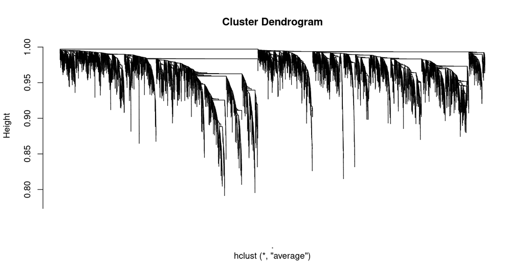

```r
dend = dissTOM %>% as.dist %>% hclust(method='average')
plot(dend, hang=0, labels=FALSE)
```

Instead of using a fixed height to cut the dendrogram into clusters, using a dynamic branch cutting approach taken from [Dynamic Tree Cut: in-depth description, tests and applications](https://horvath.genetics.ucla.edu/html/CoexpressionNetwork/BranchCutting/Supplement.pdf)

**Dynamic Hybrid Cut:** builds the clusters from bottom up. In addition to information from the dendrogram, it utilizes dissimilarity information among the objects. Seems to me that relies on too many heuristics and has too many parameters to tune. Ran it with the default settings

### Dynamic Tree Cut Algorithm

On previous experiments this method left genes too close to the root unclassified, so I’ll see if that’s happening and if the other modules make sense

- Leaves less genes without cluster than the algorithm using all the brain regions (3162 vs 4288)
- Creates many more clusters than the when using all the brain regions together (246 vs 192)

```r
modules = cutreeDynamic(dend, method = 'tree', minClusterSize = 10)

table(modules)
```

```
## modules
##    0    1    2    3    4    5    6    7    8    9   10   11   12   13   14
## 3162  634  600  531  442  347  279  263  214  214  208  206  198  168  167
##   15   16   17   18   19   20   21   22   23   24   25   26   27   28   29
##  160  159  147  146  146  144  144  130  130  126  125  118  116  115  115
##   30   31   32   33   34   35   36   37   38   39   40   41   42   43   44
##  112  111  111  104  100   93   90   90   84   83   79   77   76   73   72
##   45   46   47   48   49   50   51   52   53   54   55   56   57   58   59
##   71   66   65   64   62   61   60   60   60   58   57   57   55   55   53
##   60   61   62   63   64   65   66   67   68   69   70   71   72   73   74
##   52   52   52   51   50   50   49   47   46   46   45   44   43   43   42
##   75   76   77   78   79   80   81   82   83   84   85   86   87   88   89
##   42   42   41   41   40   40   40   39   37   37   37   36   34   34   34
##   90   91   92   93   94   95   96   97   98   99  100  101  102  103  104
##   33   33   32   32   32   32   31   31   31   31   31   31   31   31   31
```

[output cut: 20 more lines]

```r
cat(paste0(round(100*mean(modules==0)), '% of the genes are left without a cluster'))
```

```
## 20% of the genes are left without a cluster
```

```r
# Note: The modules are ordered as in the rows in datExpr
```

#### Merging similar modules

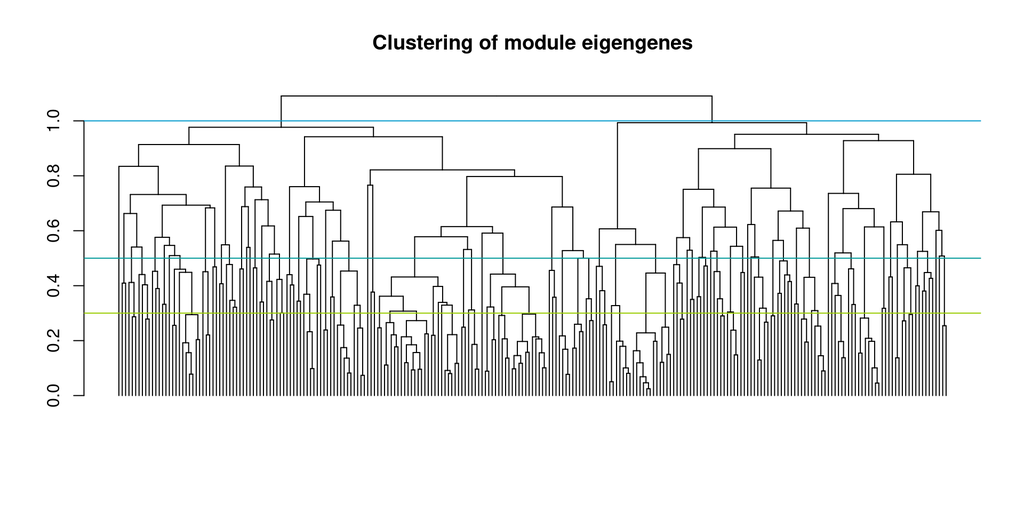

```r
# Calculate eigengenes
MEList = datExpr %>% t %>% moduleEigengenes(colors = modules)
MEs = MEList$eigengenes

# Calculate dissimilarity of module eigengenes
MEDiss = 1-cor(MEs)

# Cluster module eigengenes
METree = hclust(as.dist(MEDiss), method = 'average')

METree %>% as.dendrogram %>% plot(main = 'Clustering of module eigengenes', leaflab = 'none')
abline(h=1, col='#0099cc')
abline(h=0.5, col='#009999')
abline(h=0.3, col='#99cc00')
```

```r
merge_top = datExpr %>% t %>% mergeCloseModules(modules, cutHeight = 1)
```

```
##  mergeCloseModules: Merging modules whose distance is less than 1
##    Calculating new MEs...
```

```r
merge_similar = datExpr %>% t %>% mergeCloseModules(modules, cutHeight = 0.5)
```

```
##  mergeCloseModules: Merging modules whose distance is less than 0.5
##    Calculating new MEs...
```

```r
merge_most_similar = datExpr %>% t %>% mergeCloseModules(modules, cutHeight = 0.3)
```

```
##  mergeCloseModules: Merging modules whose distance is less than 0.3
##    Calculating new MEs...
```

```r
rm(MEList, MEs, MEDiss, METree)
```

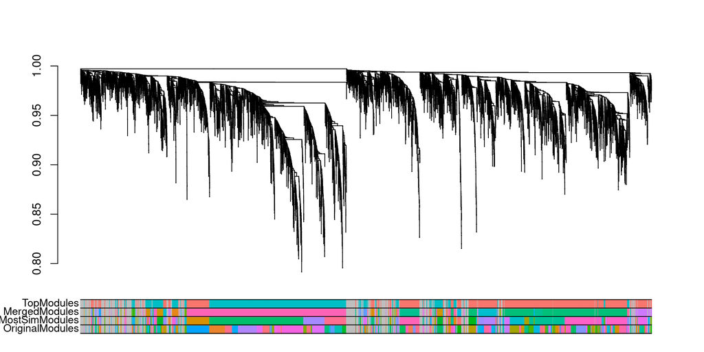

```r
get_mod_colours = function(mods){

  n = length(unique(mods))-1
  set.seed(123) ; rand_order = sample(1:n)
  mod_colors = c('gray',gg_colour_hue(n)[rand_order])
  names(mod_colors) = mods %>% table %>% names

  return(mod_colors)
}

module_colors = get_mod_colours(modules)
merged_sim_module_colors = get_mod_colours(merge_most_similar$colors)
merged_module_colors = get_mod_colours(merge_similar$colors)
top_module_colors = get_mod_colours(merge_top$colors)

dend_colors = data.frame('ID' = rownames(datExpr),
                         'OriginalModules' = module_colors[as.character(modules)],
                         'MostSimModules' = merged_sim_module_colors[as.character(merge_most_similar$colors)],
                         'MergedModules' = merged_module_colors[as.character(merge_similar$colors)],
                         'TopModules' = top_module_colors[as.character(merge_top$colors)])

dend %>% as.dendrogram(hang=0) %>% plot(ylim=c(min(dend$height),1), leaflab='none')
colored_bars(colors=dend_colors[dend$order,-1])
```

```r
rm(module_colors, merged_sim_module_colors, merged_module_colors, top_module_colors)
```

```r
modules_dynamic_tree = dend_colors

rm(dend_colors)
```

### Dynamic Hybrid Cut Algorithm

- Less genes are left without a cluster than when considering the samples from all the brain regions (32 vs 54)
- More modules than when considering all the brain regions (97 vs 59)

```r
modules = cutreeDynamic(dend, minClusterSize = 10, distM = dissTOM)
```

```
##  ..cutHeight not given, setting it to 0.996  ===>  99% of the (truncated) height range in dendro.
##  ..done.
```

```r
cat(paste0(round(100*mean(modules==0),2), '% of the genes are left without a cluster'))
```

```
## 0.2% of the genes are left without a cluster
```

```r
table(modules)
```

```
## modules
##    0    1    2    3    4    5    6    7    8    9   10   11   12   13   14
##   32 1400  616  595  587  531  518  504  489  418  400  370  352  342  328
##   15   16   17   18   19   20   21   22   23   24   25   26   27   28   29
##  316  312  299  293  287  269  265  235  209  199  195  184  174  165  162
##   30   31   32   33   34   35   36   37   38   39   40   41   42   43   44
##  162  158  151  142  137  134  128  126  121  120  119  114  113  111  108
##   45   46   47   48   49   50   51   52   53   54   55   56   57   58   59
##  104  104  102   98   97   93   93   90   88   87   86   85   85   84   82
##   60   61   62   63   64   65   66   67   68   69   70   71   72   73   74
##   82   76   75   72   72   67   62   62   61   58   57   56   54   53   49
##   75   76   77   78   79   80   81   82   83   84   85   86   87   88   89
##   47   42   42   42   40   39   38   37   37   36   33   32   31   29   28
##   90   91   92   93   94   95   96   97
##   28   28   28   27   27   24   23   16
```

#### Merging similar modules

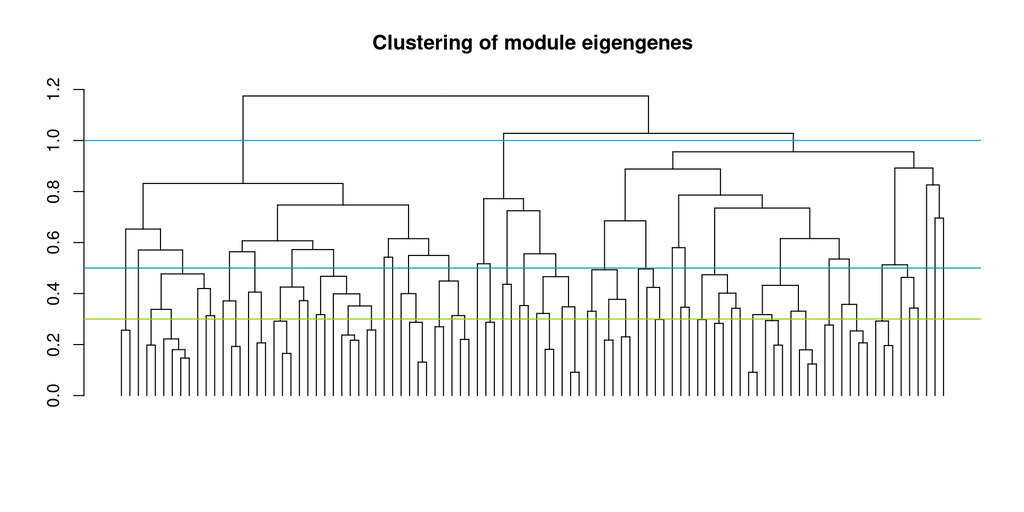

```r
# Calculate eigengenes
MEList = datExpr %>% t %>% moduleEigengenes(colors = modules)
MEs = MEList$eigengenes

# Calculate dissimilarity of module eigengenes
MEDiss = 1-cor(MEs)

# Cluster module eigengenes
METree = hclust(as.dist(MEDiss), method = 'average')

METree %>% as.dendrogram %>% plot(main = 'Clustering of module eigengenes', leaflab = 'none')
abline(h=1, col='#0099cc')
abline(h=0.5, col='#009999')
abline(h=0.3, col='#99cc00')
```

```r
merge_top = datExpr %>% t %>% mergeCloseModules(modules, cutHeight = 1)
```

```
##  mergeCloseModules: Merging modules whose distance is less than 1
##    Calculating new MEs...
```

```r
merge_similar = datExpr %>% t %>% mergeCloseModules(modules, cutHeight = 0.5)
```

```
##  mergeCloseModules: Merging modules whose distance is less than 0.5
##    Calculating new MEs...
```

```r
merge_most_similar = datExpr %>% t %>% mergeCloseModules(modules, cutHeight = 0.3)
```

```
##  mergeCloseModules: Merging modules whose distance is less than 0.3
##    Calculating new MEs...
```

```r
rm(MEList, MEs, MEDiss, METree)
```

Classification is quite noisy with respect to the dendrogram, but that isn’t necessarily a bad thing, as Peter Langfelder explains in [this blog post](https://peterlangfelder.com/2018/12/30/why-wgcna-modules-dont-always-agree-with-the-dendrogram/) from [Insights from a Million Correlations](https://peterlangfelder.com/articles/)

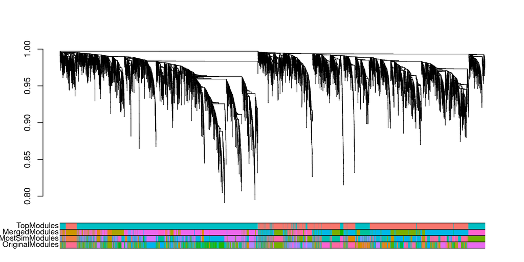

```r
module_colors = get_mod_colours(modules)
merged_sim_module_colors = get_mod_colours(merge_most_similar$colors)
merged_module_colors = get_mod_colours(merge_similar$colors)
top_module_colors = get_mod_colours(merge_top$colors)

dend_colors = data.frame('ID' = rownames(datExpr),
                         'OriginalModules' = module_colors[as.character(modules)],
                         'MostSimModules' = merged_sim_module_colors[as.character(merge_most_similar$colors)],
                         'MergedModules' = merged_module_colors[as.character(merge_similar$colors)],
                         'TopModules' = top_module_colors[as.character(merge_top$colors)])

dend %>% as.dendrogram(hang=0) %>% plot(ylim=c(min(dend$height),1), leaflab='none')
colored_bars(colors=dend_colors[dend$order,-1])
```

```r
rm(module_colors, merged_module_colors, top_module_colors)
```

```r
modules_dynamic_hybrid = dend_colors

rm(dend_colors)
```

Save clusterings file

```r
colnames(modules_dynamic_tree) = c('ID','DynamicTree', 'DynamicTreeMergedSmall', 'DynamicTreeMerged', 'DynamicTreeTop')
colnames(modules_dynamic_hybrid) = c('ID','DynamicHybrid', 'DynamicHybridMergedSmall', 'DynamicHybridMerged', 'DynamicHybridTop')

modules = modules_dynamic_tree %>% left_join(modules_dynamic_hybrid, by='ID')

write.csv(modules, file='./../Data/clusters.csv', row.names=FALSE)
```